# ANOVA Continued and Review

Day 25

Claire Kelling

Carleton College  
STAT 120 - Fall 2026

## Question of the Day

What are you looking forward to over the break? 😊

## Today’s Topics

Logistics:

- Quiz 4 questions?
- Last day of class logistics
- Last Statistician of the Week: Week 9!

Topics covered today:

- What to do if you reject the null hypothesis with ANOVA?
- Regression (Section 9.1)
- Take STAT 230 if you want more! :)

# ANOVA

## Mammalian Sleep Example

- Sample of mammal species, measure typical amount of sleep compared to general amount of danger they are in

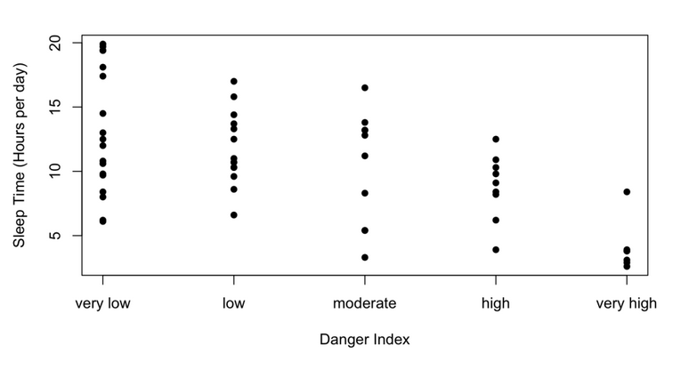

## Comparing Group Means

Overall variability in sleep time is due to two sources:

1. variability within each danger index category, and
2. variability between average sleep times for each category

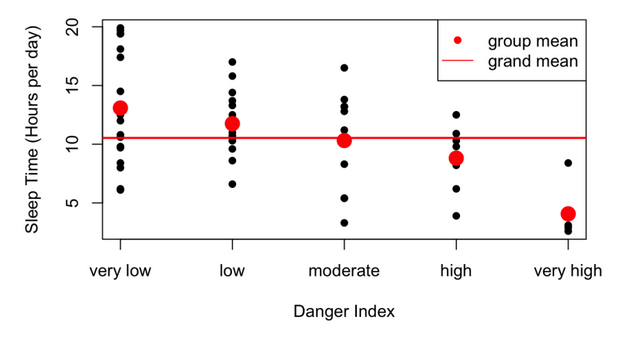

## ANOVA F-Test

R output:

```r
sleep.aov <- aov(TS~danger, data=sleep)

summary(sleep.aov)
#               Df Sum Sq Mean Sq  F value   Pr(>F)
# danger       4    457.3     114.3    8.052   3.78e-05 ***
# Residuals   53   752.4      14.2
# ---
# Signif. codes:  0 `***` 0.001 `**` 0.01 `*` 0.05 `.` 0.1 ` ` 1
```

- We have evidence that the mean sleep time is associated with the amount of danger the animal faces.
- **What is the nature of the association?**

## Post-Hoc Comparisons

- Like $\chi^2$ test, $F$ test can give evidence of association, but doesn’t tell a specific story
- **Which means are unequal** and by how much?

Recommendations:

- Look at grouped boxplots or histograms
- Give a CI for a pairwise comparison of interest?
- Once again, watch out for multiple comparisons

## Informal Comparisons

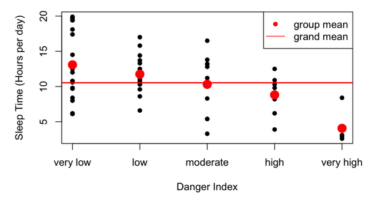

- **Finding:** Average sleep time decreases as danger increases

## Pairwise Comparison

```r
t.test(TS ~ danger, data = sleep,
   subset = (danger == `very high' | danger == `very low'))
```

```r
#   Welch Two Sample t-test
#
# data:  TS by danger
# t = 6.6301, df = 22.805, p-value = 9.57e-07
# alternative hypothesis: true difference in means between group very low and group very high is not equal to 0
# 95 percent confidence interval:
#   6.198761 11.825048
# sample estimates:
#  mean in group very low mean in group very high
#               13.083333                4.071429
```

- **Finding:** We are 95% sure that the mean sleep time for mammals facing very low danger is somewhere between 6.2 to 11.8 hours per day **greater** than for animals facing very high danger.

Also consider taking STAT 230: Applied Regression Analysis!

# Regression

## Inference for Regression

$$\hat{y} = \hat{\beta_0} + \hat{\beta_1}X$$

- We’ve already covered inference for the slope parameter using resampling.
- The “classical” inference approach relies on assumptions about a regression model.
- Similar to ANOVA assumptions:
  - Responses normally distributed within each group
  - Group standard deviations are equal

## The ANOVA Model

- **Response**: Blood pressure change
- **Explanatory**: Treatment group

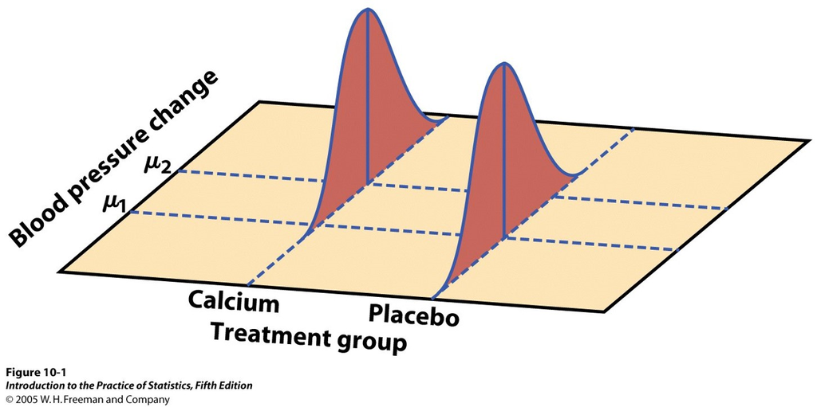

## Simple Linear Regression Model

- $\mu(Y|X) = \beta_0 + \beta_1 X$

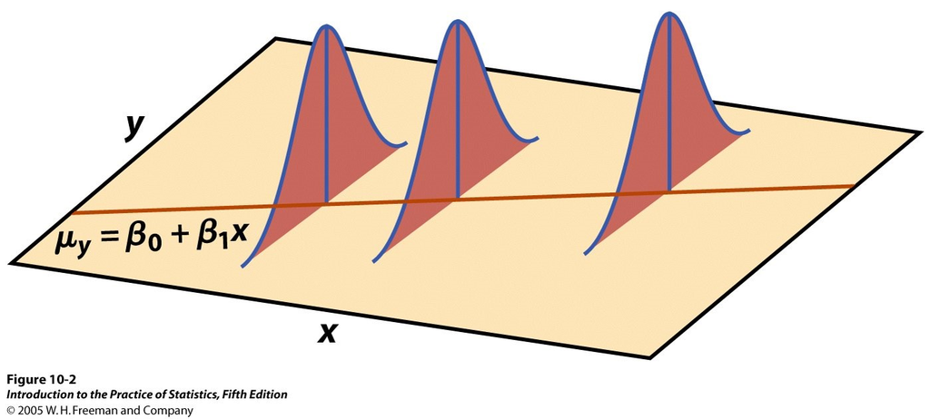

## Simple Linear Regression Model

- Mean of $Y$ is a **linear** function of X, $\hat{\mu}(Y|X) = \hat{\beta_0} + \hat{\beta_1} X$
- **Model SD** is $\sigma$ for all values of $X$
- Each value of $X$ defines a “subpopulation” of responses $Y$ which have a **normal** distribution with a mean and SD
- Assumes all observations are **independent**

Unknown population parameters:
$$\beta_0, \beta_1, \sigma$$

## Linear Regression of BAC (Y) on Beers (X)

**R Output**

```r
lin_mod <- lm(BAC~Beers, data = beer_dat)

summary(lin_mod)
# Coefficients:
#                     Estimate    Std. Error   t value      Pr(>ItI)
# (Intercept)      -0.012701    0.012638    -1.005      0.332
# Beers             0.017964    0.002402      7.480       2.97e-06 ***
#   ---
#   Signif. codes:
#   0 `***` 0.001 `**` 0.01 `*` 0.05 `.` 0.1 ` ` 1
#
# Residual standard error: 0.02044 on 14 degrees of freedom
# Multiple R-squared:  0.7998,  Adjusted R-squared:  0.7855
# F-statistic: 55.94 on 1 and 14 DF,  p-value: 2.969e-06
```

## Inference: Computer Output

- Inference uses $t$ distribution with $df = n-2$ (two coefficients)
- **Question:** Does $X$ have an effect on the mean of $Y$?
  - **Hypotheses**:
  - $H_0: \beta_i = 0$ (no effect for predictor $i$)
  - $H_a: \beta_i \neq 0$ (predictor $i$ has an effect on $y$)
  - **Test Statistic**: labeled `t value’ in R output

  $$t = \frac{\hat{\beta}_i - 0}{SE(\hat{\beta}_i)}$$
  - **P-value:** two-tailed, labeled `Pr($>ItI$)’ in R output
- **C% Confidence Interval** for $\beta_i$ is $\hat{\beta}_i \pm t^*_{df} SE(\hat{\beta}_i)$
  - Get CIs for slope/intercept with *confint* command or compute using *qt(0.975, df = )* to get $t^*$ for 95% CI

## Quiz Review!

- Every group will be assigned one problem to write on the board
- After you finish that problem, write your solution on the board
- When you are done, you can move on to a problem that your group would like to review most!
- You can reference the board (potentially with small corrections by me) for hints on where to get started

**Topics**

1. Single proportion and mean CIs
2. Chi-squared test (GOF or Association?)
3. Difference in means
4. CI interpretation
5. Difference in means
6. Chi-squared test (GOF or Association?)
7. Inference method choice

## Next Class

Quiz 4!